# CITS4009 - Project 1

Nicodemus ONG (22607943)

20 August 2023

# Introduction

The dataset analyzed can be obtained from the Kaggle platform. It’s part of the **‘Global YouTube Statistics 2023’** dataset. This dataset provides comprehensive insights into YouTube’s global statistics for the year 2023.

For more details and access to the dataset, you can visit the following link: https://www.kaggle.com/datasets/nelgiriyewithana/global-youtube-statistics-2023

The dataset offers a wealth of information about YouTube’s Youtuber performance, trends, and user engagement and many other information that functions as a valuable resource for those interested in understanding the dynamics of one of the world’s most popular online platforms.

## Youtube Link

Here is the YouTube link explaining my Shiny implementation later on: https://youtu.be/mzqJw1AdGJ0

# Overview

In this report, we will explore the process of cleaning and preprocessing YouTube data using R. The objective is to prepare the data for further analysis and insights. The script provided performs a series of steps, including package installation, data loading, formatting, special character removal, and data filtering. We will break down each step and understand its purpose. Through this report, we will delve into each step of the process, examining the rationale behind it and showcasing the associated R code. The goal is to provide a clear understanding of the data processing journey and its impact on the subsequent stages of analysis and visualization.

# Initialization

### Installing the Packages

We start by first installing and loading necessary packages such as **`tidyverse`**, **`dplyr`**, and **`stringr`** to facilitate data manipulation and transformation.

```r
install.packages("tidyverse")
install.packages("dplyr")
install.packages("stringr")
install.packages("ggthemes")
install.packages("ggplot2")
install.packages("countrycode")
install.packages("maps")
install.packages("ggmap")
install.packages("cowplot")
install.packages("rlang")
```

### Load libraries and declare special characters

Then, we address loading in the libraries.

```r
library(ggplot2)
library(dplyr)
library(stringr)
library(ggthemes)
library(gridExtra)
library(maps)
library(countrycode)
library(ggmap)
library(cowplot)
library(rlang)
```

I will set up a plotting theme so that all charts would look coherent

```r
custom_theme <- function() {
  theme_minimal() +
    theme(
      text = element_text(color = "#333333"),
      plot.title = element_text(color = "#1F497D", size = 18, face = "bold"),
      axis.title = element_text(size = 14, color = "#333333"),
      axis.text = element_text(size = 12, color = "#333333"),
      axis.line = element_line(color = "#333333"),
      legend.title = element_text(size = 12, color = "#333333"),
      legend.text = element_text(size = 10, color = "#333333"),
      panel.background = element_rect(fill = "#F2F2F2"),
      panel.grid.major = element_line(color = "#D9D9D9"),
      panel.grid.minor = element_blank(),
      plot.background = element_rect(fill = "#F2F2F2"),
      legend.background = element_rect(fill = "#FFFFFF", color = "#D9D9D9"),
      legend.key = element_rect(fill = "transparent")
    )
}

# Apply custom theme to all plots
graph_theme <- custom_theme()
```

## Data Transformation

### Reading and preprocessing of YouTube data

```r
setwd("/Users/nathanielong/Documents/Masters/CITS4009")
#1. Read in youtube data
youtube_data <- read.csv("dataset.csv")
youtube_data <- youtube_data %>%
  mutate_if(is.character, tolower)

#2. fix formatting of column names
youtube_data <- youtube_data %>%
  rename(
    gross_tertiary_education_enrollment = Gross.tertiary.education.enrollment....,
    unemployment_rate = Unemployment.rate,
    video_views = video.views
  )

#3. Rename all other columns to lowercase
colnames(youtube_data) <- tolower(colnames(youtube_data))
```

After the initial reading preprocessing of data has been done, we can better visualize the dataset through steps such as:

- Using *`str()`* to understand the structure of the data.
- Utilizing *`summary()`* for a summary of statistical measures.
- Examining the first few rows with *`head()`* to get a sense of the data.

### Checking data structure

Let’s explore the dataset’s structure using **str()**, summary statistics using **summary()**, and a preview using **head()**.

#### Structure command [*str()*]

```r
str(youtube_data)
```

```
'data.frame':   995 obs. of  28 variables:
 $ rank                               : int  1 2 3 4 5 6 7 8 9 10 ...
 $ youtuber                           : chr  "t-series" "youtube movies" "mrbeast" "cocomelon - nursery rhymes" ...
 $ subscribers                        : int  245000000 170000000 166000000 162000000 159000000 119000000 112000000 111000000 106000000 98900000 ...
 $ video_views                        : num  2.28e+11 0.00 2.84e+10 1.64e+11 1.48e+11 ...
 $ category                           : chr  "music" "film & animation" "entertainment" "education" ...
 $ title                              : chr  "t-series" "youtubemovies" "mrbeast" "cocomelon - nursery rhymes" ...
 $ uploads                            : int  20082 1 741 966 116536 0 1111 4716 493 574 ...
 $ country                            : chr  "india" "united states" "united states" "united states" ...
 $ abbreviation                       : chr  "in" "us" "us" "us" ...
 $ channel_type                       : chr  "music" "games" "entertainment" "education" ...
 $ video_views_rank                   : int  1 4055159 48 2 3 4057944 5 44 630 8 ...
 $ country_rank                       : num  1 7670 1 2 2 NaN 3 1 5 5 ...
 $ channel_type_rank                  : num  1 7423 1 1 2 ...
 $ video_views_for_the_last_30_days   : num  2.26e+09 1.20e+01 1.35e+09 1.98e+09 1.82e+09 ...
 $ lowest_monthly_earnings            : num  564600 0 337000 493800 455900 ...
 $ highest_monthly_earnings           : num  9.0e+06 5.0e-02 5.4e+06 7.9e+06 7.3e+06 ...
 $ lowest_yearly_earnings             : num  6.8e+06 4.0e-02 4.0e+06 5.9e+06 5.5e+06 ...
 $ highest_yearly_earnings            : num  1.08e+08 5.80e-01 6.47e+07 9.48e+07 8.75e+07 ...
 $ subscribers_for_last_30_days       : num  2e+06 NaN 8e+06 1e+06 1e+06 NaN NaN NaN 1e+05 6e+05 ...
 $ created_year                       : num  2006 2006 2012 2006 2006 ...
 $ created_month                      : chr  "mar" "mar" "feb" "sep" ...
 $ created_date                       : num  13 5 20 1 20 24 12 29 14 23 ...
 $ gross_tertiary_education_enrollment: num  28.1 88.2 88.2 88.2 28.1 NaN 88.2 63.2 81.9 88.2 ...
 $ population                         : num  1.37e+09 3.28e+08 3.28e+08 3.28e+08 1.37e+09 ...
 $ unemployment_rate                  : num  5.36 14.7 14.7 14.7 5.36 NaN 14.7 2.29 4.59 14.7 ...
 $ urban_population                   : num  4.71e+08 2.71e+08 2.71e+08 2.71e+08 4.71e+08 ...
 $ latitude                           : num  20.6 37.1 37.1 37.1 20.6 ...
 $ longitude                          : num  79 -95.7 -95.7 -95.7 79 ...
```

The provided output represents a data frame containing 995 observations **(rows)** and 28 variables **(columns)**. Each variable is accompanied by its data type and a brief description of its content. Among the **key variables** are *rank, youtuber, subscribers, video_views, category, title, uploads,* and others. These variables hold information such as rankings, YouTube channel names, subscriber counts, video views, categories, and more. **Numeric variables** like *subscribers, video_views, and uploads* are indicated with **int** (integer) or **num** (numeric) data types, while character variables like *youtuber, category, and title* are denoted as **chr** (character). The output provides a snapshot of the first few rows of actual data within these variables, giving a glimpse into the content of the dataset. This concise overview helps to understand the composition and structure of the data, making it easier to navigate and analyze the information within the data frame.

#### Summary command [*summary()*]

```r
summary(youtube_data)
```

```
      rank         youtuber          subscribers         video_views          category            title              uploads           country          abbreviation
 Min.   :  1.0   Length:995         Min.   : 12300000   Min.   :0.000e+00   Length:995         Length:995         Min.   :     0.0   Length:995         Length:995
 1st Qu.:249.5   Class :character   1st Qu.: 14500000   1st Qu.:4.288e+09   Class :character   Class :character   1st Qu.:   194.5   Class :character   Class :character
 Median :498.0   Mode  :character   Median : 17700000   Median :7.761e+09   Mode  :character   Mode  :character   Median :   729.0   Mode  :character   Mode  :character
 Mean   :498.0                      Mean   : 22982412   Mean   :1.104e+10                                         Mean   :  9187.1
 3rd Qu.:746.5                      3rd Qu.: 24600000   3rd Qu.:1.355e+10                                         3rd Qu.:  2667.5
 Max.   :995.0                      Max.   :245000000   Max.   :2.280e+11                                         Max.   :301308.0

 channel_type       video_views_rank   country_rank    channel_type_rank video_views_for_the_last_30_days lowest_monthly_earnings highest_monthly_earnings
 Length:995         Min.   :      1   Min.   :   1.0   Min.   :   1.0    Min.   :1.000e+00                Min.   :     0          Min.   :       0
 Class :character   1st Qu.:    323   1st Qu.:  11.0   1st Qu.:  27.0    1st Qu.:2.014e+07                1st Qu.:  2700          1st Qu.:   43500
 Mode  :character   Median :    916   Median :  51.0   Median :  65.5    Median :6.408e+07                Median : 13300          Median :  212700
                    Mean   : 554249   Mean   : 386.1   Mean   : 745.7    Mean   :1.756e+08                Mean   : 36886          Mean   :  589808
                    3rd Qu.:   3584   3rd Qu.: 123.0   3rd Qu.: 139.8    3rd Qu.:1.688e+08                3rd Qu.: 37900          3rd Qu.:  606800
                    Max.   :4057944   Max.   :7741.0   Max.   :7741.0    Max.   :6.589e+09                Max.   :850900          Max.   :13600000
                    NA's   :1         NA's   :116      NA's   :33        NA's   :56
 lowest_yearly_earnings highest_yearly_earnings subscribers_for_last_30_days  created_year  created_month       created_date   gross_tertiary_education_enrollment
 Min.   :       0       Min.   :        0       Min.   :      1              Min.   :1970   Length:995         Min.   : 1.00   Min.   :  7.60
 1st Qu.:   32650       1st Qu.:   521750       1st Qu.: 100000              1st Qu.:2009   Class :character   1st Qu.: 8.00   1st Qu.: 36.30
 Median :  159500       Median :  2600000       Median : 200000              Median :2013   Mode  :character   Median :16.00   Median : 68.00
 Mean   :  442257       Mean   :  7081814       Mean   : 349079              Mean   :2013                      Mean   :15.75   Mean   : 63.63
 3rd Qu.:  455100       3rd Qu.:  7300000       3rd Qu.: 400000              3rd Qu.:2016                      3rd Qu.:23.00   3rd Qu.: 88.20
 Max.   :10200000       Max.   :163400000       Max.   :8000000              Max.   :2022                      Max.   :31.00   Max.   :113.10
                                                NA's   :337                  NA's   :5                         NA's   :5       NA's   :123
   population        unemployment_rate urban_population       latitude        longitude
 Min.   :2.025e+05   Min.   : 0.750    Min.   :    35588   Min.   :-38.42   Min.   :-172.10
 1st Qu.:8.336e+07   1st Qu.: 5.270    1st Qu.: 55908316   1st Qu.: 20.59   1st Qu.: -95.71
 Median :3.282e+08   Median : 9.365    Median :270663028   Median : 37.09   Median : -51.93
 Mean   :4.304e+08   Mean   : 9.279    Mean   :224214982   Mean   : 26.63   Mean   : -14.13
 3rd Qu.:3.282e+08   3rd Qu.:14.700    3rd Qu.:270663028   3rd Qu.: 37.09   3rd Qu.:  78.96
 Max.   :1.398e+09   Max.   :14.720    Max.   :842933962   Max.   : 61.92   Max.   : 138.25
 NA's   :123         NA's   :123       NA's   :123         NA's   :123      NA's   :123
```

The **summary()** function is used to generate summary statistics for each variable in the data frame.

The summary also includes counts of missing values (NA’s) for each variable.

Based on the summary data provided (*e.g. rank, subscribers, video_views, uploads…*), we can see that the data is rightly-skewed

#### Head command [*head()*]

```r
head(youtube_data)
```

|  | rank | youtuber | subscribers | video_views | category | title | uploads | country | abbreviation | channel_type | video_views_rank | country_rank | channel_type_rank | video_views_for_the_last_30_days | lowest_monthly_earnings | highest_monthly_earnings | lowest_yearly_earnings | highest_yearly_earnings | subscribers_for_last_30_days | created_year | created_month | created_date | gross_tertiary_education_enrollment | population | unemployment_rate | urban_population | latitude | longitude |
| --- | --- | --- | --- | --- | --- | --- | --- | --- | --- | --- | --- | --- | --- | --- | --- | --- | --- | --- | --- | --- | --- | --- | --- | --- | --- | --- | --- | --- |
| 1 | 1 | t-series | 245000000 | 228000000000 | music | t-series | 20082 | india | in | music | 1 | 1 | 1 | 2.258e+09 | 564600 | 9.0e+06 | 6.8e+06 | 1.084e+08 | 2e+06 | 2006 | mar | 13 | 28.1 | 1366417754 | 5.36 | 471031528 | 20.59368 | 78.96288 |
| 2 | 2 | youtube movies | 170000000 | 0 | film & animation | youtubemovies | 1 | united states | us | games | 4055159 | 7670 | 7423 | 1.200e+01 | 0 | 5.0e-02 | 4.0e-02 | 5.800e-01 | NaN | 2006 | mar | 5 | 88.2 | 328239523 | 14.70 | 270663028 | 37.09024 | -95.71289 |
| 3 | 3 | mrbeast | 166000000 | 28368841870 | entertainment | mrbeast | 741 | united states | us | entertainment | 48 | 1 | 1 | 1.348e+09 | 337000 | 5.4e+06 | 4.0e+06 | 6.470e+07 | 8e+06 | 2012 | feb | 20 | 88.2 | 328239523 | 14.70 | 270663028 | 37.09024 | -95.71289 |
| 4 | 4 | cocomelon - nursery rhymes | 162000000 | 164000000000 | education | cocomelon - nursery rhymes | 966 | united states | us | education | 2 | 2 | 1 | 1.975e+09 | 493800 | 7.9e+06 | 5.9e+06 | 9.480e+07 | 1e+06 | 2006 | sep | 1 | 88.2 | 328239523 | 14.70 | 270663028 | 37.09024 | -95.71289 |
| 5 | 5 | set india | 159000000 | 148000000000 | shows | set india | 116536 | india | in | entertainment | 3 | 2 | 2 | 1.824e+09 | 455900 | 7.3e+06 | 5.5e+06 | 8.750e+07 | 1e+06 | 2006 | sep | 20 | 28.1 | 1366417754 | 5.36 | 471031528 | 20.59368 | 78.96288 |
| 6 | 6 | music | 119000000 | 0 | nan | music | 0 | nan | nan | music | 4057944 | NaN | NaN | NaN | 0 | 0.0e+00 | 0.0e+00 | 0.000e+00 | NaN | 2013 | sep | 24 | NaN | NaN | NaN | NaN | NaN | NaN |

The **head()** function displays the first few rows of the data frame, giving you a preview of its contents.

- The output shows the first 6 rows of your youtube_data data frame.
- Each row represents an observation (a YouTube channel) and each column represents a variable (attribute) associated with that channel.
- The columns include various attributes such as *rank, Youtuber, subscribers, video_views, category, title, uploads, country, abbreviation, channel_type, video_views_rank, country_rank, channel_type_rank, video_views_for_the_last_30_days, lowest_monthly_earnings, highest_monthly_earnings, lowest_yearly_earnings, highest_yearly_earnings, subscribers_for_last_30_days, created_year, created_month, created_date, gross_tertiary_education_enrollment, population, unemployment_rate, urban_population, latitude, and longitude*.
- The values in each cell of the table represent the specific information for each YouTube channel, such as their *rankings, number of subscribers, video views, category, country*, and other attributes.
- If a value is missing or not available, it is represented as *“NaN”* (Not a Number).

In summary, the output from head(youtube_data) provides a concise look at the beginning of your dataset, giving you a sense of the kind of information it contains and its structure.

### Cleaning of data

```r
#4. Replace "NaN" (case-insensitive) with blanks
youtube_data <- youtube_data %>%
  mutate_all(~ ifelse(tolower(.) == "nan", "", .)) %>%
  mutate_all(str_squish) %>%
  mutate_all(~ ifelse(str_trim(.) == "", NA, .))
```

Finally Due to the transformation steps taken, the data structure has been changed and thus we shall change it back to what is should be

```r
#5. Convert type back to original
# Convert relevant columns to numeric/integer types
numeric_columns <- c(
  "video_views",
  "country_rank", "channel_type_rank",
  "video_views_for_the_last_30_days", "lowest_monthly_earnings",
  "highest_monthly_earnings", "lowest_yearly_earnings",
  "highest_yearly_earnings", "subscribers_for_last_30_days",
  "created_year", "population", "gross_tertiary_education_enrollment",
  "unemployment_rate", "urban_population", "latitude", "longitude"
)

youtube_data <- youtube_data %>%
  mutate(across(all_of(numeric_columns), ~ as.numeric(gsub(",", "", .)))) %>%
  mutate(created_year = as.integer(created_year)) %>%
  mutate(rank = as.integer(rank)) %>%
  mutate(subscribers = as.integer(subscribers)) %>%
  mutate(uploads = as.integer(uploads)) %>%
  mutate(video_views_rank = as.integer(video_views_rank))
```

We will also add a new column called *“country_percentile_rank”*. This will be primarily calculated based of the specific Youtuber country rank.

```r
#6. Calculate country_percentile_rank
youtube_data <- youtube_data %>%
  group_by(country) %>%
  mutate(
    country_total_ranks = n(),
    country_percentile_rank = (rank(rank) - 1) / (country_total_ranks - 1)
  ) %>%
  ungroup() %>%
  mutate(country_percentile_rank = case_when(
    country_percentile_rank <= 0.2 ~ "1-20%",
    country_percentile_rank <= 0.4 ~ "21-40%",
    country_percentile_rank <= 0.6 ~ "41-60%",
    country_percentile_rank <= 0.8 ~ "61-80%",
    TRUE ~ "81-100%"
  ))
```

#### Analyzing missing values

```r
# Analyze missing values
apply(is.na(youtube_data), 2, sum)
```

```
                               rank                            youtuber                         subscribers                         video_views
                                  0                                   0                                   0                                   0
                           category                               title                             uploads                             country
                                 46                                   0                                   0                                 122
                       abbreviation                        channel_type                    video_views_rank                        country_rank
                                122                                  30                                   1                                 116
                  channel_type_rank    video_views_for_the_last_30_days             lowest_monthly_earnings            highest_monthly_earnings
                                 33                                  56                                   0                                   0
             lowest_yearly_earnings             highest_yearly_earnings        subscribers_for_last_30_days                        created_year
                                  0                                   0                                 337                                   5
                      created_month                        created_date gross_tertiary_education_enrollment                          population
                                  5                                   5                                 123                                 123
                  unemployment_rate                    urban_population                            latitude                           longitude
                                123                                 123                                 123                                 123
                country_total_ranks             country_percentile_rank
                                  0                                   0
```

### Interlinked Data Variables and Missing Values:

In the provided dataset, you’ll find a set of important variables including *latitude, longitude, unemployment rate, gross tertiary education enrollment, population, abbreviation, and country*. What’s notable about these variables is their intrinsic connection to each other through the concept of “country.” Each variable is intricately tied to the identity of a specific country.

For instance, latitude and longitude pinpoint a geographical location on Earth for each country. Unemployment rate, gross tertiary education enrollment, and population statistics provide insights into the economic and demographic characteristics of a country. Abbreviations offer standardized codes for identifying countries, while the country variable itself holds the country’s name.

#### The Missing Value Problem:

Given this interlinked nature of the variables, a significant observation arises: when information is missing for one variable, it tends to propagate to other variables as well. Imagine that data for latitude or longitude is absent for a particular country. Since these coordinates correspond to a specific geographical point, the missing latitude and longitude values would inherently affect other variables tied to that location.

For instance, if latitude and longitude are missing, it becomes difficult to accurately ascertain population, unemployment rate, and tertiary education enrollment figures for that same location. Similarly, missing information for abbreviation or country name directly influences the interpretability and integration of the other variables, as it’s challenging to attribute values to an unidentified country.

Hence without the primary information of latitude and longitude, it will be impossible to identify the country and the other respective information.

#### Replacing missing values where applicable

based on the previous observation, we can see that *channel_type, country, category* are two categorical values that can be replaced with a new category all in itself. We shall put them under “others”.

```r
# Replace NA values with a new category
youtube_data$channel_type[is.na(youtube_data$channel_type)] <- "others"
youtube_data$country[is.na(youtube_data$country)] <- "others"
youtube_data$category[is.na(youtube_data$category)] <- "others"
youtube_data$abbreviation[is.na(youtube_data$abbreviation)] <- "others"
```

as for *video_views_for_the_last_30_days* and *subscribers_for_last_30_days*, we can make the assumption that NA means they have 0 growth hence we will replace the NA values as 0

```r
# Replace NA values with 0
youtube_data$subscribers_for_last_30_days[is.na(youtube_data$subscribers_for_last_30_days)] <- 0
youtube_data$video_views_for_the_last_30_days[is.na(youtube_data$video_views_for_the_last_30_days)] <- 0
```

## Visualization

### Analyzing Subscribers and Video Views

Since these are right-skewed variables, we’ll use two histograms to analyze the distribution: one with a log10 scale and one with a truncated linear scale

##### Log10 Scale Histogram

- Advantages: A log10 scale histogram is particularly useful for visualizing the distribution of highly skewed variables. It can help in spreading out the data and making patterns more apparent, especially when there’s a wide range of values. It allows you to better observe the variations in the lower range while also giving an idea of the higher values. This can be especially helpful when dealing with variables like subscribers, views, or earnings that have both small and extremely large values.
- Drawbacks: While a log10 scale can reveal patterns in the data, it may not be immediately intuitive to all viewers. Interpretation of the axis ticks and values can require a bit more cognitive effort.

##### Truncated Linear Scale Histogram

- Advantages: A truncated linear scale histogram maintains the original scale of the data while cutting off extreme values for better visualization of the main distribution. This can be helpful when you want to focus on the majority of the data and remove the influence of outliers. It’s generally more intuitive for viewers who are not familiar with log scales.
- Drawbacks: Truncating the scale might result in a compressed view of the distribution, potentially making it difficult to identify the presence of outliers or the finer details of the tail.

**using both histograms can provide a more comprehensive understanding of the data’s distribution**

#### Subscribers

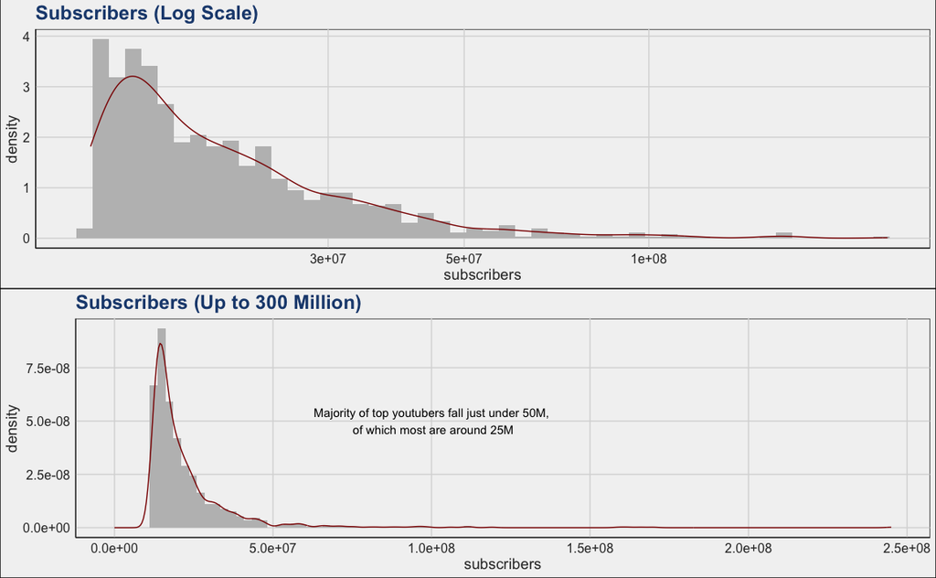

```r
p1_subscribers <- ggplot(data = youtube_data, mapping = aes(x = subscribers)) +
  geom_histogram(aes(y = ..density..), bins = 50, fill = "grey") +
  geom_density(color = 'darkred') +
  scale_x_continuous(trans = 'log10') +
  ggtitle("Subscribers (Log Scale)") +
  graph_theme

p2_subscribers <- ggplot(data = youtube_data, mapping = aes(x = subscribers)) +
  geom_histogram(aes(y = ..density..), bins = 100, fill = "grey") +
  geom_density(color = 'darkred') +
  scale_x_continuous(limits = c(0, 2.45e+08), breaks = seq(0, 3e+08, by = 5e+07)) +
  ggtitle("Subscribers (Up to 300 Million)") +
  annotate("text", x = 1e+08, y = 5.0e-08, label = "Majority of top youtubers fall just under 50M,\n of which most are around 25M") +
  graph_theme
grid.arrange(p1_subscribers, p2_subscribers, ncol = 1)
```

As we can see, majority of the top content creators have just under 50M subscribers although there are still some outliers that are well over that number

#### Video Views

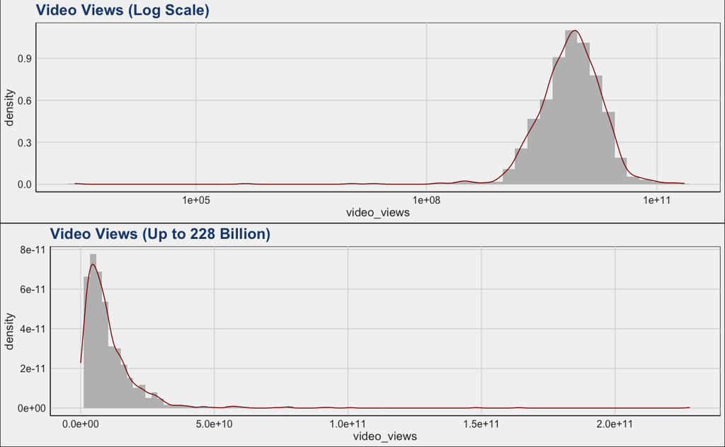

```r
# Analyzing Video Views
p1_video_views <- ggplot(data = youtube_data, mapping = aes(x = video_views)) +
  geom_histogram(aes(y = ..density..), bins = 50, fill = "grey") +
  geom_density(color = 'darkred') +
  scale_x_continuous(trans = 'log10') +
  ggtitle("Video Views (Log Scale)") +
  graph_theme

p2_video_views <- ggplot(data = youtube_data, mapping = aes(x = video_views)) +
  geom_histogram(aes(y = ..density..), bins = 100, fill = "grey") +
  geom_density(color = 'darkred') +
  scale_x_continuous(limits = c(0, 2.280e+11)) +
  ggtitle("Video Views (Up to 228 Billion)") +
  graph_theme
grid.arrange(p1_video_views, p2_video_views, ncol = 1)
```

Similarly, video views of the top youtubers congregate near the 10B mark with certain outliers that are higher

#### Correlation between both subscriber and youtuber

We can further represent the data and see if there is any correlation between a high/low subscribed youtuber vs high/low video views of said youtuber

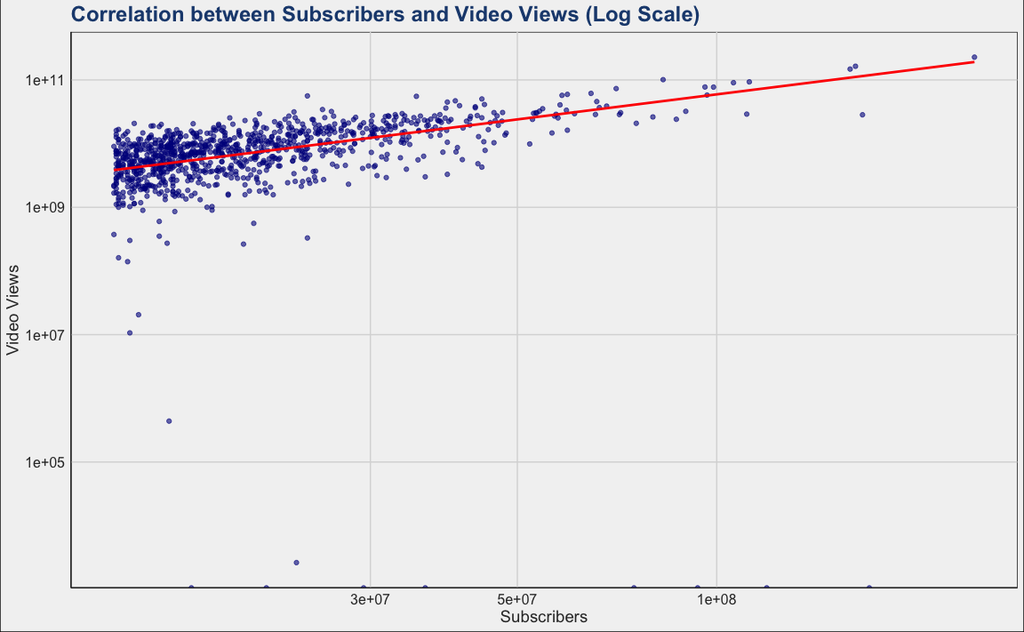

```r
correlation_plot <- ggplot(data = youtube_data, aes(x = subscribers, y = video_views)) +
  geom_point(alpha = 0.6, color = 'darkblue') +
  geom_smooth(method = "lm", se = FALSE, color = "red") +  # Adding the trendline
  scale_x_continuous(trans = 'log10') +
  scale_y_continuous(trans = 'log10') +
  ggtitle("Correlation between Subscribers and Video Views (Log Scale)") +
  xlab("Subscribers") + ylab("Video Views") +
  graph_theme
grid.arrange(correlation_plot, ncol = 1)
```

Based on the scatter plot graph, we can see distinctively that there is a trend line threading upwards showing that the higher the subscriber count it, it correlates to having a higher video view count as well.

### Analyzing Youtuber countries and population

```r
highest_data <- youtube_data %>%
  group_by(country) %>%
  summarize(population = max(population, na.rm = TRUE),
            urban_population = max(urban_population, na.rm = TRUE),
            longitude = max(longitude, na.rm = TRUE),
            latitude = max(latitude, na.rm = TRUE)) %>%
  ungroup() %>%
  left_join(select(youtube_data, country, abbreviation), by = "country") %>%
  distinct(country, population, urban_population, longitude, latitude, abbreviation)
# Use the countrycode library to add the actual country code
highest_data <- highest_data %>%
  mutate(country_code = countrycode(country, origin = "country.name", destination = "iso3c"))
highest_data <- highest_data %>%
  arrange(population) %>%
  mutate(country = factor(country, levels = country))  # Reorder the factor levels
```

Now, we want to represent the population of each country and demonstrate how certain countries have significantly more population compared to the others hence why their views or subscribers may be more.

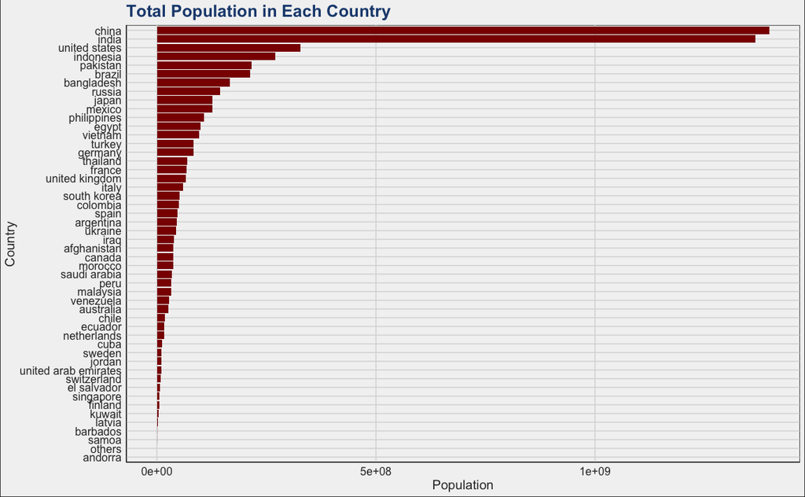

```r
population_bar_plot <- ggplot(highest_data, aes(x = country, y = population)) +
  geom_bar(stat = "identity", fill = "darkred") +
  coord_flip() +
  labs(title = "Total Population in Each Country",
       x = "Country",
       y = "Population") +
  graph_theme
grid.arrange(population_bar_plot, ncol = 1)
```

Building off this, there is a suspicion that the countries with a high overall population may also have a significant number of citizens who live in urbanized residential areas.

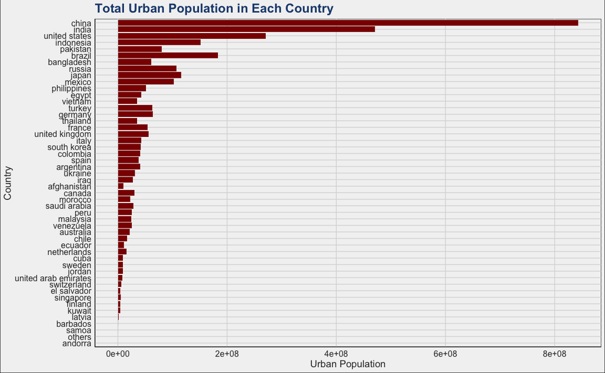

```r
urban_population_bar_plot <- ggplot(highest_data, aes(x = country, y = urban_population)) +
  geom_bar(stat = "identity", fill = "darkred") +
  coord_flip() +
  labs(title = "Total Urban Population in Each Country",
       x = "Country",
       y = "Urban Population") +
  graph_theme

grid.arrange(urban_population_bar_plot, ncol = 1)
```

Now with these two graphs available, we can combined them both into a single graph to show the difference between them.

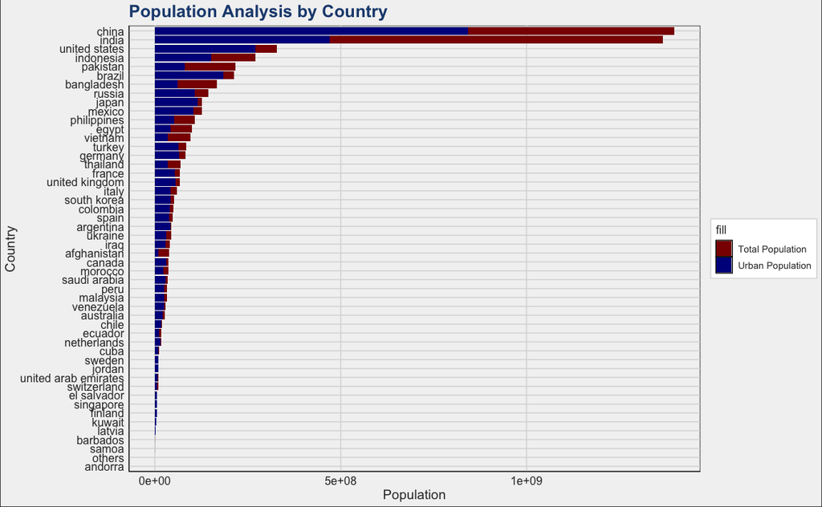

```r
combined_bar_plot <- ggplot(highest_data, aes(x = country)) +
  geom_bar(aes(y = population, fill = "Total Population"), stat = "identity", position = "stack") +
  geom_bar(aes(y = urban_population, fill = "Urban Population"), stat = "identity", position = "stack") +
  coord_flip() +
  labs(title = "Population Analysis by Country",
       x = "Country",
       y = "Population") +
  scale_fill_manual(values = c("Total Population" = "darkred", "Urban Population" = "darkblue")) +
  graph_theme
grid.arrange(combined_bar_plot, ncol = 1)
```

as suspected, countries with a huge population also has a huge number of citizens who live in urbanized residence.

#### Better visualization with maps

For a better visualization as to where the populations are more dense across the countries, it is easier to visualize them across a map.

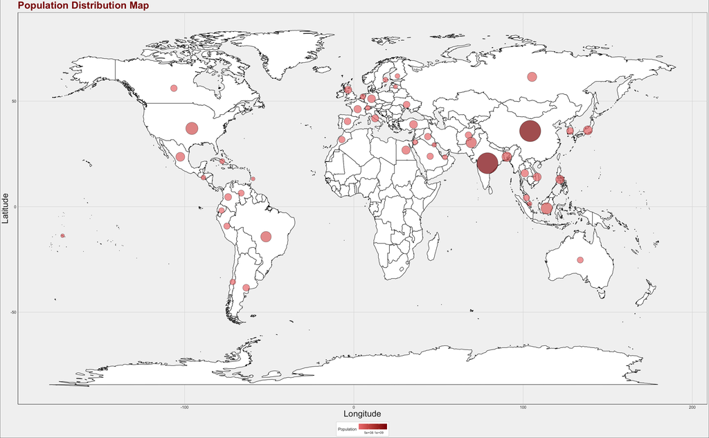

```r
# Create population map
world_map_data <- map_data("world")

# Create the population map plot with world map background
population_map_plot <- ggplot() +
  geom_map(data = world_map_data, map = world_map_data,
           aes(x = long, y = lat, map_id = region), color = "black", fill = "white") +
  geom_point(data = highest_data, aes(x = longitude, y = latitude, size = population, fill = population),
             shape = 21, color = "black", alpha = 0.7, show.legend = TRUE) +  # Set alpha to adjust transparency
  scale_fill_gradient(low = "lightcoral", high = "darkred", na.value = "transparent", guide = "colorbar") +
  scale_size_continuous(range = c(5, 30), guide = FALSE) +  # Remove size legend
  labs(title = "Population Distribution Map",
       x = "Longitude",
       y = "Latitude",
       fill = "Population") +
  graph_theme +
  theme(plot.title = element_text(color = "darkred", size = 30, face = "bold")) +
  theme(axis.title = element_text(color = "#202020", size = 26)) +
  theme(legend.position = "bottom")  # Move the legend to the bottom
grid.arrange(population_map_plot, ncol = 1)
```

With this, we can clearly see that China and India has the most densely population compared to the other parts of the world.

### Analyzing correlation between uploads and ranking

To begin, we first have to calculate the ranking of each youtuber specific to their country. This means that their percentile is determined based off their countries data rather than globally as a whole.

```r
youtube_data <- youtube_data %>%
  group_by(country) %>%
  mutate(
    country_total_ranks = n(),
    country_percentile_rank = (rank(rank) - 1) / (country_total_ranks - 1)
  ) %>%
  ungroup() %>%
  mutate(country_percentile_rank = case_when(
    country_percentile_rank <= 0.2 ~ "1-20%",
    country_percentile_rank <= 0.4 ~ "21-40%",
    country_percentile_rank <= 0.6 ~ "41-60%",
    country_percentile_rank <= 0.8 ~ "61-80%",
    TRUE ~ "81-100%"
  ))
```

Once that is done, we can represent it in a plot where the Y axis shows the number of uploads and the X axis shows the ranking.

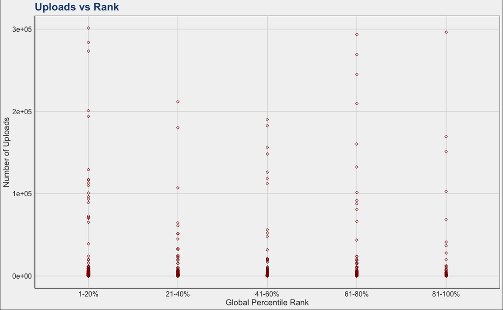

```r
ggplot(youtube_data, aes(x = country_percentile_rank, y = uploads)) +
      geom_point(colour = "darkred", shape = 23) +
      geom_smooth() +
      labs(
        title = "Uploads vs Rank",
        x = "Global Percentile Rank",
        y = "Number of Uploads"
      ) +
      graph_theme
```

However, as we can see from this it is not a useful representation as each Youtuber is ranked based of their country rank rather than a global rank. Hence why we should use the Shiny Application for this to demonstrate each country’s data and information.

## Shiny Application

### Youtube Link

Here is the YouTube link explaining my Shiny implementation: https://youtu.be/mzqJw1AdGJ0

Firstly, the Shiny App library has to be installed and imported.

```r
install.packages("Shiny")
library(shiny)
```

next we would then need to setup up the side panel with the plots avaiable as well as the countries and each plot’s specific configuration.

```r
# Define UI
ui <- fluidPage(
  titlePanel("Youtube Data Plot Selection"),

  sidebarLayout(
    sidebarPanel(
      style = "max-height: calc(100vh - 50px); overflow-y: auto; width: 300px; position: fixed;",  # Adjusted width and added position
      selectInput("plot_type", "Select Plot Type", choices = c("Channel Category Plot", "Rank Percentile Plot", "Earnings Plot")),
      selectInput("country_chart", "Select Country", choices = unique(youtube_data$country)),
      uiOutput("channel_type_ui"),
      conditionalPanel(
        condition = "input.plot_type == 'Rank Percentile Plot'",
        checkboxInput("correlation_checkbox", "Show Video views vs rank Plot", value = FALSE)
      ),
      conditionalPanel(
        condition = "input.plot_type == 'Earnings Plot'",
        radioButtons("earnings_time_period", "Select Earnings Time Period",
                     choices = c("Monthly", "Yearly"), selected = "Monthly"),
        radioButtons("earnings_value_type", "Select Earnings Value Type",
                     choices = c("Highest", "Lowest"), selected = "Highest")
      ),

      hr()
    ),
    mainPanel(
      style = "margin-left: 350px;",  # Adjusted margin-left
      uiOutput("dynamic_plot"),
      verbatimTextOutput("total_youtubers_count")
    )
  )
)
```

Note that I have chosen to include total youtuber count in as well just so that we can better understand how many youtubers were used to achieve the numbers on the plots

after which we then have to configure the server with the relevant conditions for each specific plot selected from the UI

```r
server <- function(input, output, session) {

  total_youtubers_count <- reactiveVal(0)  # Initialize with 0

  observe({
    if (!is.null(input$country_chart)) {
      total_youtubers_count(nrow(filtered_data_chart()))
    }
  })

  output$total_youtubers_count <- renderText({
    paste("Total YouTubers in", input$country_chart, "used for this plot:", total_youtubers_count())
  })

  output$channel_type_ui <- renderUI({
    if (input$plot_type == "Channel Category Plot") {
      selectInput("channel_type", "Select Channel Type", choices = c("All", unique(youtube_data$channel_type)))
    } else {
      NULL
    }
  })

  filtered_data_chart <- reactive({
    if (!is.null(input$channel_type) && input$channel_type != "All") {
      filtered_data <- youtube_data[youtube_data$country == input$country_chart &
                                      youtube_data$channel_type == input$channel_type, ]
    } else {
      filtered_data <- youtube_data[youtube_data$country == input$country_chart, ]
    }
    filtered_data
  })

  output$dynamic_plot <- renderUI({
    plot_type <- input$plot_type

    if (plot_type == "Channel Category Plot") {
      plotOutput("stacked_bar_chart")
    } else if (plot_type == "Rank Percentile Plot") {
      plotOutput("percentile_scatter_plot")
    } else if (plot_type == "Earnings Plot") {
      plotOutput("earning_plot")
    }
  })
```

### Analyzing data for Channel Category types

in this plot, the main objective is to visualize the number of uploads from each category. Ontop of that, out of all that uploads what are their channel types. Since we have 3 different variables here, the best representation of this is to use a stacked coloured bar chart.

```r
output$stacked_bar_chart <- renderPlot({
    data_for_plot <- filtered_data_chart()  # Store the reactive data in a variable
    ggplot(data_for_plot, aes(x = category, y = uploads, fill = channel_type)) +
      geom_bar(stat = "identity") +
      labs(title = "Country Channel Type Category Data",
           x = "Category",
           y = "Uploads",
           fill = "Channel Type") +
      graph_theme +
      coord_flip() +
      theme(legend.position = "bottom",
            text = element_text(face = "bold"),  # Bold text
            plot.title = element_text(size = rel(1.2))) +
      scale_fill_discrete(name = "Channel Type")
  })
```

An included option is to allow you to select channel type, this further drills down the data and allows you to see for that specific channel type what categories do they exist in.

### Analyzing data for Youtuber rank based on uploads vs video views

in this plot, we want to see if the total number of uploads affects the Ranking percentile of the youtubers from that specific country. To achieve this, we first have to assign each youtuber a percentile ranking based on their country rank. Remember from the previous part that this was already done during the data transformation.

```r
  output$percentile_scatter_plot <- renderPlot({
    data_for_plot <- filtered_data_chart()  # Store the reactive data in a variable
    p <- ggplot(data_for_plot, aes(x = country_percentile_rank, y = uploads)) +
      geom_point(colour = "darkred", shape = 23) +
      labs(title = "Country Rank Data",
           x = "Top Percentile Rank",
           y = "Uploads") +
      theme(legend.position = "bottom",
            text = element_text(face = "bold", size = 12),  # Bold text
            plot.title = element_text(size = rel(1.2))) +
      graph_theme
```

lets try to demonstrate it now with video views rather than uploads

```r
 if (input$correlation_checkbox) {
      correlation_plot <- ggplot(data_for_plot, aes(x = video_views, y = country_percentile_rank)) +
        geom_point(colour = "darkblue", shape = 23) +
        geom_smooth(method = "lm", se = FALSE, color = "darkblue") +
        labs(title = "Correlation between Video Views and Percentile Rank",
             x = "Video Views",
             y = "Percentile Rank") +
        theme(legend.position = "bottom",
              text = element_text(face = "bold", size = 12),  # Bold text
              plot.title = element_text(size = rel(1.2))) +
        graph_theme
      p <- cowplot::plot_grid(p, correlation_plot, nrow = 2)
    }
```

### Analyzing earnings of each countries youtubers

For this plot, we are trying to represent the data in a box plot to show the spread of earnings for both yearly/monthly as well as if they were the lowest or the highest. However due to the data being heavily skewed towards one side, the box plot for certain countries may not be a clear representation.

to counter this, I have also included a violin plot to better represent the data and show where the majority of the spread is.

```r
  output$earning_plot <- renderPlot({
    data_for_plot <- filtered_data_chart()

    earnings_type <- if (input$earnings_time_period == "Monthly") {
      if (input$earnings_value_type == "Highest") {
        "highest_monthly_earnings"
      } else {
        "lowest_monthly_earnings"
      }
    } else {
      if (input$earnings_value_type == "Highest") {
        "highest_yearly_earnings"
      } else {
        "lowest_yearly_earnings"
      }
    }

    if (earnings_type %in% names(data_for_plot)) {
      mean_earnings <- mean(data_for_plot[[earnings_type]], na.rm = TRUE)
      p_box <- ggplot(data_for_plot, aes(x = factor(1), y = .data[[earnings_type]])) +
        geom_boxplot() +
        stat_summary(fun = mean, geom = "point", shape = 19, size = 3, color = "red") +  # Adding mean dot
        geom_text(aes(x = 1, y = mean_earnings, label = paste("Mean")),
                  vjust = -1, color = "red") +
        labs(title = paste(mean_earnings, input$earnings_value_type, "Earnings Box Plot -", input$earnings_time_period, mean_earnings),
             x = "",
             y = "Earnings") +
        theme(legend.position = "bottom",
              text = element_text(face = "bold", size = 12),  # Bold text
              plot.title = element_text(size = rel(1.2))) +
        graph_theme +
        scale_x_discrete(labels = "")

      p_violin <- ggplot(data_for_plot, aes(x = factor(1), y = .data[[earnings_type]])) +
        geom_violin(fill = "lightblue", color = "blue", alpha = 0.5) +
        stat_summary(fun = mean, geom = "point", shape = 19, size = 3, color = "red") +  # Adding mean dot
        geom_text(aes(x = 1, y = mean_earnings, label = paste("Mean")),
                  vjust = -1, color = "red") +
        labs(title = paste(input$earnings_value_type, "Earnings Violin Plot -", input$earnings_time_period),
             x = "",
             y = "Earnings") +
        theme(legend.position = "bottom",
              text = element_text(face = "bold", size = 12),  # Bold text
              plot.title = element_text(size = rel(1.2))) +
        graph_theme +
        scale_x_discrete(labels = "")

      plot_grid(p_box, p_violin, ncol = 2)
    } else {
      # Return a message if the selected earnings column is not present
      plot(NULL, xlim = c(0, 1), ylim = c(0, 1), xlab = "", ylab = "",
           main = "Selected earnings column not found.")
    }
  })
```